# Youth Risk Behavior Surveillance

2017-10-31T22:26:13-05:00

# Youth Risk Behavior Surveillance

## Exploratory Data Analysis

Using visualization and summary statistics, describe the distribution of weights. How many observations are we missing weights from? Use also the skim function.

```r
data(yrbss)

# Create summary statistics
summary(yrbss$weight)
```

```
##    Min. 1st Qu.  Median    Mean 3rd Qu.    Max.    NA's
##      30      56      64      68      76     181    1004
```

```r
skimr::skim(yrbss)
```

Data summary

| Name | yrbss |
| --- | --- |
| Number of rows | 13583 |
| Number of columns | 13 |
| _______________________ |  |
| Column type frequency: |  |
| character | 8 |
| numeric | 5 |
| ________________________ |  |
| Group variables | None |

**Variable type: character**

| skim_variable | n_missing | complete_rate | min | max | empty | n_unique | whitespace |
| --- | --- | --- | --- | --- | --- | --- | --- |
| gender | 12 | 1.00 | 4 | 6 | 0 | 2 | 0 |
| grade | 79 | 0.99 | 1 | 5 | 0 | 5 | 0 |
| hispanic | 231 | 0.98 | 3 | 8 | 0 | 2 | 0 |
| race | 2805 | 0.79 | 5 | 41 | 0 | 5 | 0 |
| helmet_12m | 311 | 0.98 | 5 | 12 | 0 | 6 | 0 |
| text_while_driving_30d | 918 | 0.93 | 1 | 13 | 0 | 8 | 0 |
| hours_tv_per_school_day | 338 | 0.98 | 1 | 12 | 0 | 7 | 0 |
| school_night_hours_sleep | 1248 | 0.91 | 1 | 3 | 0 | 7 | 0 |

**Variable type: numeric**

| skim_variable | n_missing | complete_rate | mean | sd | p0 | p25 | p50 | p75 | p100 | hist |
| --- | --- | --- | --- | --- | --- | --- | --- | --- | --- | --- |
| age | 77 | 0.99 | 16.16 | 1.26 | 12.00 | 15.0 | 16.00 | 17.00 | 18.00 | ▁▂▅▅▇ |
| height | 1004 | 0.93 | 1.69 | 0.10 | 1.27 | 1.6 | 1.68 | 1.78 | 2.11 | ▁▅▇▃▁ |
| weight | 1004 | 0.93 | 67.91 | 16.90 | 29.94 | 56.2 | 64.41 | 76.20 | 180.99 | ▆▇▂▁▁ |
| physically_active_7d | 273 | 0.98 | 3.90 | 2.56 | 0.00 | 2.0 | 4.00 | 7.00 | 7.00 | ▆▂▅▃▇ |
| strength_training_7d | 1176 | 0.91 | 2.95 | 2.58 | 0.00 | 0.0 | 3.00 | 5.00 | 7.00 | ▇▂▅▂▅ |

```r
# Plot missing values
kable(yrbss%>%
  filter(is.na(weight))%>%
  summarise(Toatal_missing_data=n()),"simple")
```

| Toatal_missing_data |
| --- |
| 1004 |

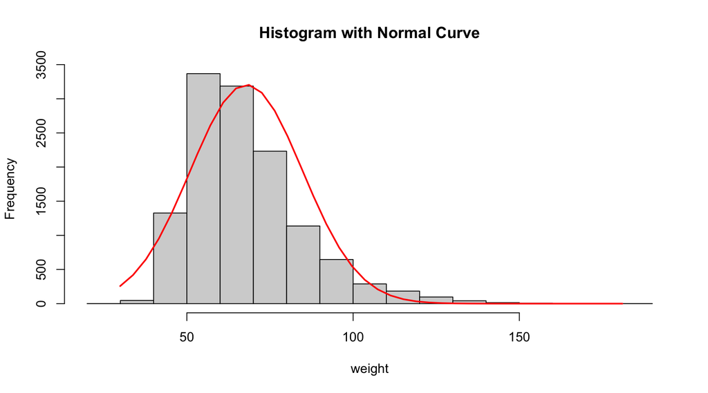

```r
# Create histogram
x <- yrbss$weight
h<-hist(x,
        xlab="weight", main="Histogram with Normal Curve")

# Create normal distribution as comparison
xfit<-seq(min(x,na.rm = TRUE),max(x,na.rm = TRUE),length=40)               #  order the data
yfit<-dnorm(xfit,mean=mean(x,na.rm = TRUE),sd=sd(x,na.rm = TRUE))          #  density of normal dis
yfit <- yfit*diff(h$mids[1:2])*length(x)
lines(xfit, yfit, col="red", lwd=2)
```

**Answer:**

The minimum value of weight is 30, the maximum value is 181, the median is 64, the lower quantile is 56, the upper quantile is 76, and the total number of missing values is 1004. The distribution of weights looks lightly skewed to the right. We added a normal distribution line as comparison.

Let’s create a new variable in the dataframe `yrbss`, called `physical_3plus` , which will be `yes` if they are physically active for at least 3 days a week, and `no` otherwise. Use the `count()` function and see if you get the same results as `group_by()... summarise()`. Also plot your data.

```r
# Create new variable
yrbss$physical_3plus<-ifelse(yrbss$physically_active_7d>=3,"yes","no")

# Method group_by()... summarise()
yrbss%>%
  group_by(physical_3plus)%>%
  summarise(n=n())%>%
  mutate(prop=label_percent()(n/nrow(yrbss)))
```

```
## # A tibble: 3 × 3
##   physical_3plus     n prop
##   <chr>          <int> <chr>
## 1 no              4404 32%
## 2 yes             8906 66%
## 3 <NA>             273 2%
```

```r
# Method count()
yrbss%>%
count(physical_3plus) %>%
mutate(prop=label_percent()(n/nrow(yrbss)))
```

```
## # A tibble: 3 × 3
##   physical_3plus     n prop
##   <chr>          <int> <chr>
## 1 no              4404 32%
## 2 yes             8906 66%
## 3 <NA>             273 2%
```

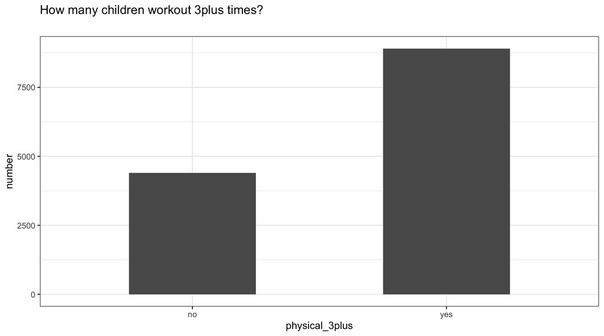

```r
# Create a graph to show difference
yrbss%>%
  filter(is.na(physical_3plus)==FALSE)%>%
  group_by(physical_3plus)%>%
  summarise(number=n())%>%
ggplot(aes(x=physical_3plus,y=number))+
  geom_bar(stat = "identity",width =0.5)+
  labs(x="physical_3plus",y="number")+
  ggtitle("How many children workout 3plus times?",
          subtitle = "")+
  theme_bw()
```

**Answer:**

In this first analysis we have separately shown the percentage proportion also for the NA values. 8906 kids practice sport 3plus times a week while 4404 do not. In the graph we have not included the NA values.

## Confidence Interval for Proportion 3plus

Can you provide a 95% confidence interval for the population proportion of high schools that are *NOT* active 3 or more days per week?

```r
#Filtering data

test<-yrbss %>%
  filter(is.na(physical_3plus)==FALSE)%>%

# Changing yes no to numerical value to make it easier
  mutate(physical_3_p=ifelse(physical_3plus=="yes",1,0), physical_3_l=ifelse(physical_3plus=="no",1,0))


# With formula

ci_yrbss <- test %>%
  filter(!is.na(physical_3plus)) %>%
  summarize(count = n(),
            p = (sum(physical_3plus == "no"))/count,
            t_critical = qt(0.975, count-1),
            se_diff = sqrt(p*(1-p)/count),
            margin_of_error = t_critical * se_diff,
            prop_low = p - margin_of_error,
            prop_high = p + margin_of_error)

# print the table with confidence interval

kable(ci_yrbss,
      caption="CI 3 or more times active Formula")
```

CI 3 or more times active Formula

| count | p | t_critical | se_diff | margin_of_error | prop_low | prop_high |
| --- | --- | --- | --- | --- | --- | --- |
| 13310 | 0.331 | 1.96 | 0.004 | 0.008 | 0.323 | 0.339 |

```r
# Confidence Interval with bootstrap

set.seed(1234)
boot_3lower <- test %>%
# Select
  filter(is.na(physical_3plus)==FALSE)%>%
# Specify the variable of interest
  specify(response = physical_3_l) %>%
# Generate a bunch of bootstrap samples
  generate(reps = 1000, type = "bootstrap") %>%
  calculate(stat = "mean")

percentile_ci<- boot_3lower %>%
   get_confidence_interval(level=0.95, type="percentile")
kable(percentile_ci,
      caption="CI 3 or more times active Infer")
```

CI 3 or more times active Infer

| lower_ci | upper_ci |
| --- | --- |
| 0.323 | 0.338 |

**Answer:**

The 95% confidence interval is [0.323,0.339] calculated with both, formula and bootstrap.

## Boxplot 3plus

Make a boxplot of `physical_3plus` vs. `weight`. Is there a relationship between these two variables? What did you expect and why?

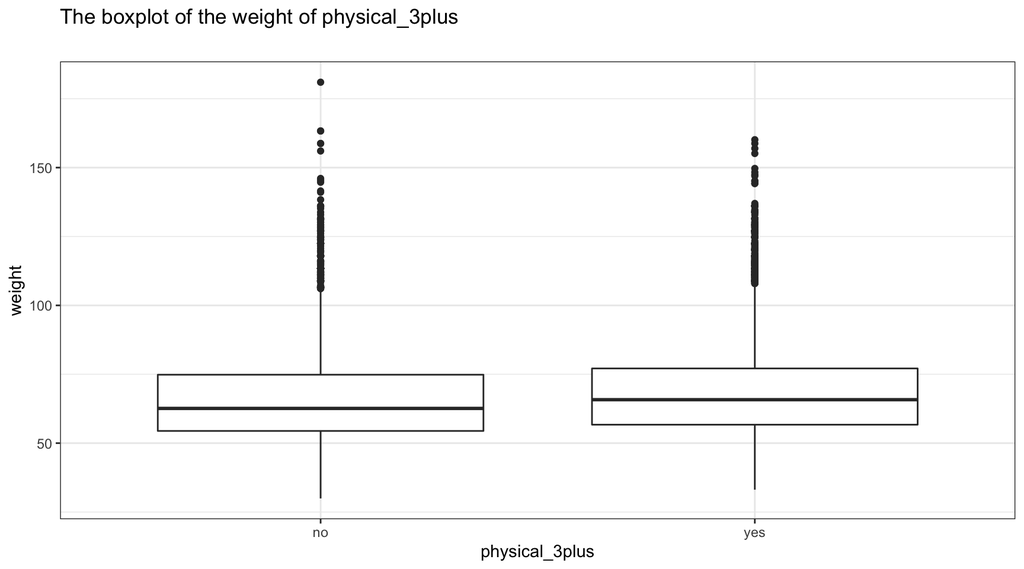

```r
# Create boxplot

yrbss%>%
  filter(is.na(physical_3plus)==FALSE)%>%
ggplot(aes(x=physical_3plus,y=weight))+
  geom_boxplot()+
  ggtitle("The boxplot of the weight of physical_3plus",
          subtitle = "")+
  theme_bw()
```

**Answer:**

Although almost similiar, there is a positive relationship between being physically active for at least 3 days a week and weight. The result is somehow counter-intuitive, since we thought that more exercise in children would reduce there weight. This might be explained by the reason that people who stay highly active take part of physically demanding sports like basket, football and similiar and have thus a higher percentage of muscle or are just bigger. One additional reason could be that kids who are slightly heavier are more incentivised to exercise more frequently.

## Confidence Interval Weight by Formula

Calculate the mean, SD, etc. weight in these groups using the mean function, we must ignore any missing values by setting the `na.rm = TRUE`and define confidence interval.

```r
#Apllying formula to weight
ci_yrbss_weight <- yrbss %>%
  filter(is.na(physical_3plus)==FALSE)%>%
  group_by(physical_3plus) %>%
  summarize(mean = mean(weight, na.rm=TRUE),
            sd = sd(weight, na.rm=TRUE),
            count = n(),
            t_critical = qt(0.975, count-1),
            se_diff = sd/sqrt(count),
            margin_of_error = t_critical * se_diff,
            weight_low = mean - margin_of_error,
            weight_high = mean + margin_of_error)

#Plotting results
kable(ci_yrbss_weight)
```

| physical_3plus | mean | sd | count | t_critical | se_diff | margin_of_error | weight_low | weight_high |
| --- | --- | --- | --- | --- | --- | --- | --- | --- |
| no | 66.7 | 17.6 | 4404 | 1.96 | 0.266 | 0.521 | 66.2 | 67.2 |
| yes | 68.4 | 16.5 | 8906 | 1.96 | 0.175 | 0.342 | 68.1 | 68.8 |

There is an observed mean difference of about 1.77kg (68.44 - 66.67), and we notice that the two confidence intervals do not overlap. It seems that the difference is statistically significant at 95% confidence. Let us however also conduct a hypothesis test.